# R Notebook

# Assignment 1

# 1. Dataset selection

## Insert and running required packages

[@xie2018r] [@allaire2023rmarkdown] [@xie2020r] [@Zhu2021] [@Müller2023] [@Wickham2022] [@Davis2007] [@Morgan2022] [@zhu2008geometadb] [@durinck2009mapping] [@durinck2005biomart] [@drost2017biomartr] [@loraine2015analysis] [@robinson2010edger] [@Wickham2022dev] [@Dervieux2022] [@Xie2023kni] [@Xie2015kni] [@Stodden2014] [@gu2022complex] [@gu2016complex] [@gu2014circlize]

```r
if (!requireNamespace("rmarkdown", quietly = TRUE))
    +     install.packages("rmarkdown")
if (!requireNamespace("knitr", quietly = TRUE))
    +     install.packages("knitr")
if (!requireNamespace("devtools", quietly = TRUE))
    +     install.packages("devtools")
if (!requireNamespace("BiocManager", quietly = TRUE))
    +     install.packages("BiocManager")
if (!requireNamespace("edgeR", quietly = TRUE))
    BiocManager::install("edgeR")
if (!requireNamespace("biomaRt", quietly = TRUE))
    BiocManager::install("biomaRt")
if (!requireNamespace("GEOmetadb", quietly = TRUE))
    BiocManager::install("GEOmetadb")
if (!requireNamespace("GEOquery", quietly = TRUE))
    +     install.packages("GEOquery")
if (!requireNamespace("DBI", quietly = TRUE))
    +     install.packages("DBI")
if (!requireNamespace("RSQLite", quietly = TRUE))
    +     install.packages("RSQLite")
if(!requireNamespace("kableExtra", quietly=TRUE))
    install.packages("kableExtra")
if(!requireNamespace("ComplexHeatmap", quietly=TRUE))
    install.packages("ComplexHeatmap")
if(!requireNamespace("circlize", quietly=TRUE))
    install.packages("circlize")
if(!requireNamespace("functional", quietly=TRUE))
    install.packages("functional")
```

```r
library(devtools)
library(rmarkdown)
library(knitr)
library(BiocManager)
library(GEOmetadb)
library(GEOquery)
library(DBI)
library(RSQLite)
library(edgeR)
library(biomaRt)
library(kableExtra)
library(ComplexHeatmap)
library(circlize)
library(functional)
```

## Dataset Selection Criteria

```r
sql <- paste("SELECT DISTINCT gse.title,gse.gse, gpl.title,",
             " gse.submission_date,",
             " gse.supplementary_file",
             "FROM",
             "  gse JOIN gse_gpl ON gse_gpl.gse=gse.gse",
             "  JOIN gpl ON gse_gpl.gpl=gpl.gpl",
             "WHERE",
             "  gse.submission_date > '2013-01-01' AND",
             "  gse.title LIKE '%colon cancer%' AND",
             "  gpl.organism LIKE '%Homo sapiens%' AND",
             "  gpl.technology LIKE '%high-throughput sequencing%' ",
             "  ORDER BY gse.submission_date DESC",sep=" ")
```

Selecting series with counts data

```r
if(!file.exists('GEOmetadb.sqlite')) getSQLiteFile()
con <- dbConnect(SQLite(),'GEOmetadb.sqlite')
rs <- dbGetQuery(con,sql)
counts_files <- rs$supplementary_file[grep(rs$supplementary_file,
                              pattern = "count|cnt",ignore.case = TRUE)]

series_of_interest <- rs$gse[grep(rs$supplementary_file,
                              pattern = "count|cnt",ignore.case = TRUE)]

shortened_filenames <- unlist(lapply(counts_files,
             FUN = function(x){x <- unlist(strsplit(x,";")) ;
              x <- x[grep(x,pattern= "count|cnt",ignore.case = TRUE)];
               tail(unlist(strsplit(x,"/")),n=1)}))
shortened_filenames[1:10]
```

```
 [1] "GSE161349_Counts_noadj_exons_condense.txt.gz" "GSE152430_raw_gene_count_matrix.txt.gz"
 [3] "GSE147111_ReadCounts.csv.gz"                  "GSE146009_Caucasian_RawCounts.txt.gz"
 [5] "GSE142314_countsMatrix_normalized.csv.gz"     "GSE125282_CC36_and_CC14_Raw_counts_all.xlsx"
 [7] "GSE118504_SSAP_NormalizedReadCounts.xls.gz"   "GSE98922_counts.txt.gz"
 [9] "GSE92432_gene_count_matrix.csv.gz"            "GSE82236_miRNA_counts.txt.gz"
```

The first 10 outputs of the interested series show studies focused on colorectal genomics, and hold the selection criteria. After quick reviewing, I chose GSE98922 [@schmidt2018targeting].

## Details of the Selected Series

Number of entities

```r
gse <- getGEO("GSE98922",GSEMatrix=FALSE)
```

[output not shown]

Data owner contact information

```r
kable(data.frame(head(Meta(gse))), format = "pipe")
```

| contact_address | contact_city | contact_country | contact_department | contact_email | contact_institute |
| --- | --- | --- | --- | --- | --- |
| Feodor-Lynen-Str. 25 | Munich | Germany | Gene Center | krebs-st@lmb.uni-muenchen.de | Ludwig-Maximilian University |

Name and number of the samples

```r
names(GSMList(gse))
```

```
[1] "GSM2627682" "GSM2627683" "GSM2627684" "GSM2627685" "GSM2627686" "GSM2627687" "GSM2627688"
[8] "GSM2627689" "GSM2627690"
```

Series includes 9 samples.

More information about the series

```r
show(getGEO("GSE98922",GSEMatrix=TRUE))
```

```
Found 1 file(s)
GSE98922_series_matrix.txt.gz
Using locally cached version: /tmp/RtmpHPWTCU/GSE98922_series_matrix.txt.gz
Using locally cached version of GPL18460 found here:
/tmp/RtmpHPWTCU/GPL18460.soft.gz
```

```
$GSE98922_series_matrix.txt.gz
ExpressionSet (storageMode: lockedEnvironment)
assayData: 0 features, 9 samples
  element names: exprs
protocolData: none
phenoData
  sampleNames: GSM2627682 GSM2627683 ... GSM2627690 (9 total)
  varLabels: title geo_accession ... tissue:ch1 (46 total)
  varMetadata: labelDescription
featureData: none
experimentData: use 'experimentData(object)'
  pubMedIds: 29769248
Annotation: GPL18460
```

Samples classification

```r
data.frame(getGEO("GSE98922",GSEMatrix=TRUE)[[1]])[,]
```

```
Found 1 file(s)
GSE98922_series_matrix.txt.gz
Using locally cached version: /tmp/RtmpHPWTCU/GSE98922_series_matrix.txt.gz
Warning: call dbDisconnect() when finished working with a connection
Using locally cached version of GPL18460 found here:
/tmp/RtmpHPWTCU/GPL18460.soft.gz
```

|  | title | geo_accession | status | submission_date | last_update_date | type | channel_count | source_name_ch1 | organism_ch1 | characteristics_ch1 | characteristics_ch1.1 | treatment_protocol_ch1 | growth_protocol_ch1 | molecule_ch1 | extract_protocol_ch1 | extract_protocol_ch1.1 | taxid_ch1 | description | data_processing | data_processing.1 | data_processing.2 | data_processing.3 | data_processing.4 | data_processing.5 | data_processing.6 | platform_id | contact_name | contact_email | contact_phone | … |
| --- | --- | --- | --- | --- | --- | --- | --- | --- | --- | --- | --- | --- | --- | --- | --- | --- | --- | --- | --- | --- | --- | --- | --- | --- | --- | --- | --- | --- | --- | --- |
| GSM2627682 | vehicle treatment rep1 | GSM2627682 | Public on Apr 18 2018 | May 15 2017 | May 15 2019 | SRA | 1 | SW480 | Homo sapiens | agent: vehicle | tissue: xenograft | mice were treated daily with 1.25 mg selumetinib (AZD6244, Selleckchem) p.o. or 0.35 mg dibenzazepine (DBZ, Axon Medchem) i.p. for 5 days. | SW480 cells were suspended in 100 μl of a 1:1 mixture of PBS and growth factor-depleted Matrigel (Corning), and injected subcutaneously into 6-8 week old NOD/SCID mice (NOD.CB17-Prkdcscid, The Jackson… | total RNA | RNA was isolated from tumor xenografts using TRIzol (Invitrogen) | 500ng of total RNA were used for library generation using mRNA SENSE kit from Lexogen strictly following the manufacturer's protocol | 9606 | control1 | Basecalling was done by RTA1.18.64 | Truseq adapter and polyA were removed | reads were aligned to the human genome by STAR RNAseq read mapper | reads overlapping with annotated genes were counted with HTseq count | rlog transformation was done by DESeq2 | Genome_build: hg19 | Supplementary_files_format_and_content: raw count table from HTseq count and rlog tranformed expression values from DEseq2 | GPL18460 | Stefan,,Krebs | krebs-st@lmb.uni-muenchen.de | 0049-89-2180 76715 | … |
| GSM2627683 | vehicle treatment rep2 | GSM2627683 | Public on Apr 18 2018 | May 15 2017 | May 15 2019 | SRA | 1 | SW480 | Homo sapiens | agent: vehicle | tissue: xenograft | mice were treated daily with 1.25 mg selumetinib (AZD6244, Selleckchem) p.o. or 0.35 mg dibenzazepine (DBZ, Axon Medchem) i.p. for 5 days. | SW480 cells were suspended in 100 μl of a 1:1 mixture of PBS and growth factor-depleted Matrigel (Corning), and injected subcutaneously into 6-8 week old NOD/SCID mice (NOD.CB17-Prkdcscid, The Jackson… | total RNA | RNA was isolated from tumor xenografts using TRIzol (Invitrogen) | 500ng of total RNA were used for library generation using mRNA SENSE kit from Lexogen strictly following the manufacturer's protocol | 9606 | control2 | Basecalling was done by RTA1.18.64 | Truseq adapter and polyA were removed | reads were aligned to the human genome by STAR RNAseq read mapper | reads overlapping with annotated genes were counted with HTseq count | rlog transformation was done by DESeq2 | Genome_build: hg19 | Supplementary_files_format_and_content: raw count table from HTseq count and rlog tranformed expression values from DEseq2 | GPL18460 | Stefan,,Krebs | krebs-st@lmb.uni-muenchen.de | 0049-89-2180 76715 | … |
| GSM2627684 | vehicle treatment rep3 | GSM2627684 | Public on Apr 18 2018 | May 15 2017 | May 15 2019 | SRA | 1 | SW480 | Homo sapiens | agent: vehicle | tissue: xenograft | mice were treated daily with 1.25 mg selumetinib (AZD6244, Selleckchem) p.o. or 0.35 mg dibenzazepine (DBZ, Axon Medchem) i.p. for 5 days. | SW480 cells were suspended in 100 μl of a 1:1 mixture of PBS and growth factor-depleted Matrigel (Corning), and injected subcutaneously into 6-8 week old NOD/SCID mice (NOD.CB17-Prkdcscid, The Jackson… | total RNA | RNA was isolated from tumor xenografts using TRIzol (Invitrogen) | 500ng of total RNA were used for library generation using mRNA SENSE kit from Lexogen strictly following the manufacturer's protocol | 9606 | control3 | Basecalling was done by RTA1.18.64 | Truseq adapter and polyA were removed | reads were aligned to the human genome by STAR RNAseq read mapper | reads overlapping with annotated genes were counted with HTseq count | rlog transformation was done by DESeq2 | Genome_build: hg19 | Supplementary_files_format_and_content: raw count table from HTseq count and rlog tranformed expression values from DEseq2 | GPL18460 | Stefan,,Krebs | krebs-st@lmb.uni-muenchen.de | 0049-89-2180 76715 | … |
| GSM2627685 | AZD treatment rep1 | GSM2627685 | Public on Apr 18 2018 | May 15 2017 | May 15 2019 | SRA | 1 | SW480 | Homo sapiens | agent: AZD | tissue: xenograft | mice were treated daily with 1.25 mg selumetinib (AZD6244, Selleckchem) p.o. or 0.35 mg dibenzazepine (DBZ, Axon Medchem) i.p. for 5 days. | SW480 cells were suspended in 100 μl of a 1:1 mixture of PBS and growth factor-depleted Matrigel (Corning), and injected subcutaneously into 6-8 week old NOD/SCID mice (NOD.CB17-Prkdcscid, The Jackson… | total RNA | RNA was isolated from tumor xenografts using TRIzol (Invitrogen) | 500ng of total RNA were used for library generation using mRNA SENSE kit from Lexogen strictly following the manufacturer's protocol | 9606 | TreatmentA1 | Basecalling was done by RTA1.18.64 | Truseq adapter and polyA were removed | reads were aligned to the human genome by STAR RNAseq read mapper | reads overlapping with annotated genes were counted with HTseq count | rlog transformation was done by DESeq2 | Genome_build: hg19 | Supplementary_files_format_and_content: raw count table from HTseq count and rlog tranformed expression values from DEseq2 | GPL18460 | Stefan,,Krebs | krebs-st@lmb.uni-muenchen.de | 0049-89-2180 76715 | … |
| GSM2627686 | AZD treatment rep2 | GSM2627686 | Public on Apr 18 2018 | May 15 2017 | May 15 2019 | SRA | 1 | SW480 | Homo sapiens | agent: AZD | tissue: xenograft | mice were treated daily with 1.25 mg selumetinib (AZD6244, Selleckchem) p.o. or 0.35 mg dibenzazepine (DBZ, Axon Medchem) i.p. for 5 days. | SW480 cells were suspended in 100 μl of a 1:1 mixture of PBS and growth factor-depleted Matrigel (Corning), and injected subcutaneously into 6-8 week old NOD/SCID mice (NOD.CB17-Prkdcscid, The Jackson… | total RNA | RNA was isolated from tumor xenografts using TRIzol (Invitrogen) | 500ng of total RNA were used for library generation using mRNA SENSE kit from Lexogen strictly following the manufacturer's protocol | 9606 | TreatmentA2 | Basecalling was done by RTA1.18.64 | Truseq adapter and polyA were removed | reads were aligned to the human genome by STAR RNAseq read mapper | reads overlapping with annotated genes were counted with HTseq count | rlog transformation was done by DESeq2 | Genome_build: hg19 | Supplementary_files_format_and_content: raw count table from HTseq count and rlog tranformed expression values from DEseq2 | GPL18460 | Stefan,,Krebs | krebs-st@lmb.uni-muenchen.de | 0049-89-2180 76715 | … |
| GSM2627687 | AZD treatment rep3 | GSM2627687 | Public on Apr 18 2018 | May 15 2017 | May 15 2019 | SRA | 1 | SW480 | Homo sapiens | agent: AZD | tissue: xenograft | mice were treated daily with 1.25 mg selumetinib (AZD6244, Selleckchem) p.o. or 0.35 mg dibenzazepine (DBZ, Axon Medchem) i.p. for 5 days. | SW480 cells were suspended in 100 μl of a 1:1 mixture of PBS and growth factor-depleted Matrigel (Corning), and injected subcutaneously into 6-8 week old NOD/SCID mice (NOD.CB17-Prkdcscid, The Jackson… | total RNA | RNA was isolated from tumor xenografts using TRIzol (Invitrogen) | 500ng of total RNA were used for library generation using mRNA SENSE kit from Lexogen strictly following the manufacturer's protocol | 9606 | TreatmentA3 | Basecalling was done by RTA1.18.64 | Truseq adapter and polyA were removed | reads were aligned to the human genome by STAR RNAseq read mapper | reads overlapping with annotated genes were counted with HTseq count | rlog transformation was done by DESeq2 | Genome_build: hg19 | Supplementary_files_format_and_content: raw count table from HTseq count and rlog tranformed expression values from DEseq2 | GPL18460 | Stefan,,Krebs | krebs-st@lmb.uni-muenchen.de | 0049-89-2180 76715 | … |
| GSM2627688 | DBZ treatment rep1 | GSM2627688 | Public on Apr 18 2018 | May 15 2017 | May 15 2019 | SRA | 1 | SW480 | Homo sapiens | agent: DBZ | tissue: xenograft | mice were treated daily with 1.25 mg selumetinib (AZD6244, Selleckchem) p.o. or 0.35 mg dibenzazepine (DBZ, Axon Medchem) i.p. for 5 days. | SW480 cells were suspended in 100 μl of a 1:1 mixture of PBS and growth factor-depleted Matrigel (Corning), and injected subcutaneously into 6-8 week old NOD/SCID mice (NOD.CB17-Prkdcscid, The Jackson… | total RNA | RNA was isolated from tumor xenografts using TRIzol (Invitrogen) | 500ng of total RNA were used for library generation using mRNA SENSE kit from Lexogen strictly following the manufacturer's protocol | 9606 | TreatmentD1 | Basecalling was done by RTA1.18.64 | Truseq adapter and polyA were removed | reads were aligned to the human genome by STAR RNAseq read mapper | reads overlapping with annotated genes were counted with HTseq count | rlog transformation was done by DESeq2 | Genome_build: hg19 | Supplementary_files_format_and_content: raw count table from HTseq count and rlog tranformed expression values from DEseq2 | GPL18460 | Stefan,,Krebs | krebs-st@lmb.uni-muenchen.de | 0049-89-2180 76715 | … |
| GSM2627689 | DBZ treatment rep2 | GSM2627689 | Public on Apr 18 2018 | May 15 2017 | May 15 2019 | SRA | 1 | SW480 | Homo sapiens | agent: DBZ | tissue: xenograft | mice were treated daily with 1.25 mg selumetinib (AZD6244, Selleckchem) p.o. or 0.35 mg dibenzazepine (DBZ, Axon Medchem) i.p. for 5 days. | SW480 cells were suspended in 100 μl of a 1:1 mixture of PBS and growth factor-depleted Matrigel (Corning), and injected subcutaneously into 6-8 week old NOD/SCID mice (NOD.CB17-Prkdcscid, The Jackson… | total RNA | RNA was isolated from tumor xenografts using TRIzol (Invitrogen) | 500ng of total RNA were used for library generation using mRNA SENSE kit from Lexogen strictly following the manufacturer's protocol | 9606 | TreatmentD2 | Basecalling was done by RTA1.18.64 | Truseq adapter and polyA were removed | reads were aligned to the human genome by STAR RNAseq read mapper | reads overlapping with annotated genes were counted with HTseq count | rlog transformation was done by DESeq2 | Genome_build: hg19 | Supplementary_files_format_and_content: raw count table from HTseq count and rlog tranformed expression values from DEseq2 | GPL18460 | Stefan,,Krebs | krebs-st@lmb.uni-muenchen.de | 0049-89-2180 76715 | … |
| GSM2627690 | DBZ treatment rep3 | GSM2627690 | Public on Apr 18 2018 | May 15 2017 | May 15 2019 | SRA | 1 | SW480 | Homo sapiens | agent: DBZ | tissue: xenograft | mice were treated daily with 1.25 mg selumetinib (AZD6244, Selleckchem) p.o. or 0.35 mg dibenzazepine (DBZ, Axon Medchem) i.p. for 5 days. | SW480 cells were suspended in 100 μl of a 1:1 mixture of PBS and growth factor-depleted Matrigel (Corning), and injected subcutaneously into 6-8 week old NOD/SCID mice (NOD.CB17-Prkdcscid, The Jackson… | total RNA | RNA was isolated from tumor xenografts using TRIzol (Invitrogen) | 500ng of total RNA were used for library generation using mRNA SENSE kit from Lexogen strictly following the manufacturer's protocol | 9606 | TreatmentD3 | Basecalling was done by RTA1.18.64 | Truseq adapter and polyA were removed | reads were aligned to the human genome by STAR RNAseq read mapper | reads overlapping with annotated genes were counted with HTseq count | rlog transformation was done by DESeq2 | Genome_build: hg19 | Supplementary_files_format_and_content: raw count table from HTseq count and rlog tranformed expression values from DEseq2 | GPL18460 | Stefan,,Krebs | krebs-st@lmb.uni-muenchen.de | 0049-89-2180 76715 | … |

There are 3 groups in the study, including 3 vehicle_treated, 3 AZD_treated, and 3 DBZ_treated; total 9 samples.

## Platform details

```r
current_gpl <- names(GPLList(gse))[1]
current_gpl_info <- Meta(getGEO(current_gpl))
```

```
Using locally cached version of GPL18460 found here:
/tmp/RtmpHPWTCU/GPL18460.soft.gz
```

**Platform accession number:**

```r
current_gpl_info$geo_accession
```

```
[1] "GPL18460"
```

**Platform title:**

```r
current_gpl_info$title
```

```
[1] "Illumina HiSeq 1500 (Homo sapiens)"
```

**Submission date:**

```r
current_gpl_info$submission_date
```

```
[1] "Mar 24 2014"
```

**Last update date:**

```r
current_gpl_info$last_update_date
```

```
[1] "Oct 02 2018"
```

**Organisms:**

```r
current_gpl_info$organism
```

```
[1] "Homo sapiens"
```

**Technology:**

```r
current_gpl_info$technology
```

```
[1] "high-throughput sequencing"
```

**Number of GEO datasets that use this technology:*

```r
length(current_gpl_info$series_id)
```

```
[1] 333
```

**Number of GEO samples that use this technology:**

```r
length(current_gpl_info$sample_id)
```

```
[1] 6440
```

# 2. Data expression

Supplementary files

```r
supp_files = getGEOSuppFiles('GSE98922')
file_names = rownames(supp_files)
print(file_names)
```

```
[1] "/home/rstudio/projects/Documents/BCB420/Maryam_Hasanzadehkiabi/Assignment 2/GSE98922/GSE98922_counts.txt.gz"
[2] "/home/rstudio/projects/Documents/BCB420/Maryam_Hasanzadehkiabi/Assignment 2/GSE98922/GSE98922_rlog_transformed.txt.gz"
```

There are two supplementary files provided for this dataset, one includes counts data and the other one contains rlog_transformed data[@schmidt2018targeting]. Researchers studied NOTCH, MAPK, and WNT pathways signaling effect on a total 328 adenocarcinoma. Tumor cells located at the tumor edge with MAPK and WNT high activity showed epithelial-mesenchymal transition (EMT) phenotype, while tumor cells located at the tumor center showed more epithelial phenotype [@schmidt2018targeting]. Counts file is being used for further analysis.

```r
genes_expression = read.delim(file_names[1],header=TRUE,
          check.names = FALSE)
```

In the following section, number of the genes and name of the variables included in the dataset are presented; since the first column includes gene names without column name, “hgnc_symbol” is assigned to the first column name.

```r
dim(genes_expression)
```

```
[1] 23373    10
```

```r
colnames(genes_expression)[1] <- "hgnc_symbol"
colnames(genes_expression)
```

```
 [1] "hgnc_symbol" "control1"    "control2"    "control3"    "TreatmentA1" "TreatmentA2"
 [7] "TreatmentA3" "TreatmentD1" "TreatmentD2" "TreatmentD3"
```

Samples category

Considering the treatment agent, there are 3 groups including vehicle-treated tumors (controls), MEK inhibitor-treated (selumetinib (AZD)), and γ-secretase inhibitor-treated (dibenzazepine (DBZ)); each group contains 3 replicates.

```r
dataSamples <- data.frame(lapply(colnames(genes_expression)[2:10],
FUN=function(x){substr(x, 1, nchar(x)-1)}))
colnames(dataSamples) <- colnames(genes_expression)[2:10]
dataSamples <- data.frame(t(dataSamples))
dataSamples[dataSamples == "control"] <- "Vehicle"
dataSamples[dataSamples == "TreatmentA"] <- "AZD"
dataSamples[dataSamples == "TreatmentD"] <- "DBZ"
colnames(dataSamples) <- "Agent"

dataSamples_control_versus_TReatmentA <- data.frame(lapply(colnames(genes_expression)[2:7],
FUN=function(x){substr(x, 1, nchar(x)-1)}))
colnames(dataSamples_control_versus_TReatmentA) <- colnames(genes_expression)[2:7]
dataSamples_control_versus_TReatmentA <- data.frame(t(dataSamples_control_versus_TReatmentA))
dataSamples_control_versus_TReatmentA[dataSamples_control_versus_TReatmentA == "control"] <- "Vehicle"
dataSamples_control_versus_TReatmentA[dataSamples_control_versus_TReatmentA == "TreatmentA"] <- "AZD"
colnames(dataSamples_control_versus_TReatmentA) <- "Agent"
```

# 3. Genes cleaning and filtering

## Duplication

Checking potential duplication. If the logical output returns any “TRUE” value, there does exist duplication. Otherwise the set contains unique genes.

```r
summary(duplicated(genes_expression$hgnc_symbol))
```

```
   Mode   FALSE
logical   23373
```

```r
summary(is.na(genes_expression$hgnc_symbol))
```

```
   Mode   FALSE
logical   23373
```

Since there is no “TRUE” value in the output, dataset dose not include any duplicate or missing value genes.

## Outliers

```r
cpms = cpm(genes_expression[,2:10])
rownames(cpms) <- genes_expression$hgnc_symbol
keep = rowSums(cpms > 2) >=3
genes_filtered = genes_expression[keep,]
```

## Data distribution before normalization

Boxplot

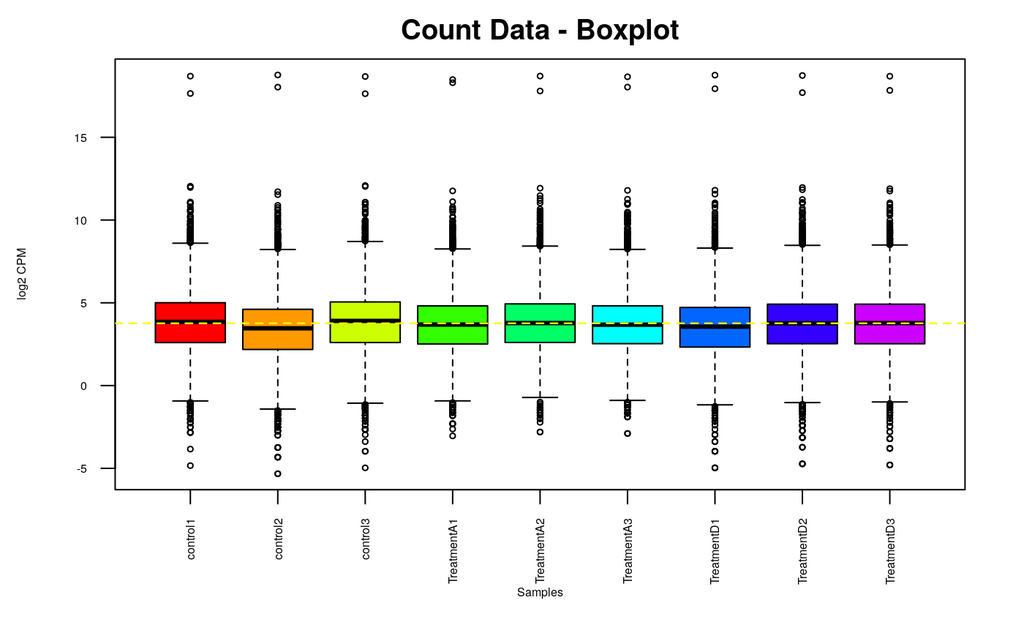

```r
data2plot <- log2(cpm(genes_filtered[,2:10]))
colnames(data2plot) <- colnames(genes_filtered)[2:10]
boxplot(data2plot, xlab = "Samples", ylab = "log2 CPM",
las = 2, cex = 0.5, cex.lab = 0.5,
cex.axis = 0.5, main = "Count Data - Boxplot", col=rainbow(10))
abline(h = median(apply(data2plot, 2, median)),
col = "yellow", lwd = 1.2, lty = "dashed")
```

Outliers with negative infinity are not drawn in plot.

Density plot

```r
counts_density <- apply(log2(cpm(genes_filtered[,2:10])),
2, density)
xlim <- 0; ylim <- 0
for (i in 1:length(counts_density)) {
xlim <- range(c(xlim, counts_density[[i]]$x));
ylim <- range(c(ylim, counts_density[[i]]$y))
}
cols <- rainbow(length(counts_density))
ltys <- rep(1, length(counts_density))
plot(counts_density[[1]], xlim=xlim, ylim=ylim, type="n",
ylab="Smoothing density of log2-CPM",
main="Count Data Density Plot", cex.lab = 0.85)
for (i in 1:length(counts_density))
lines(counts_density[[i]], col=cols[i], lty=ltys[i])
```

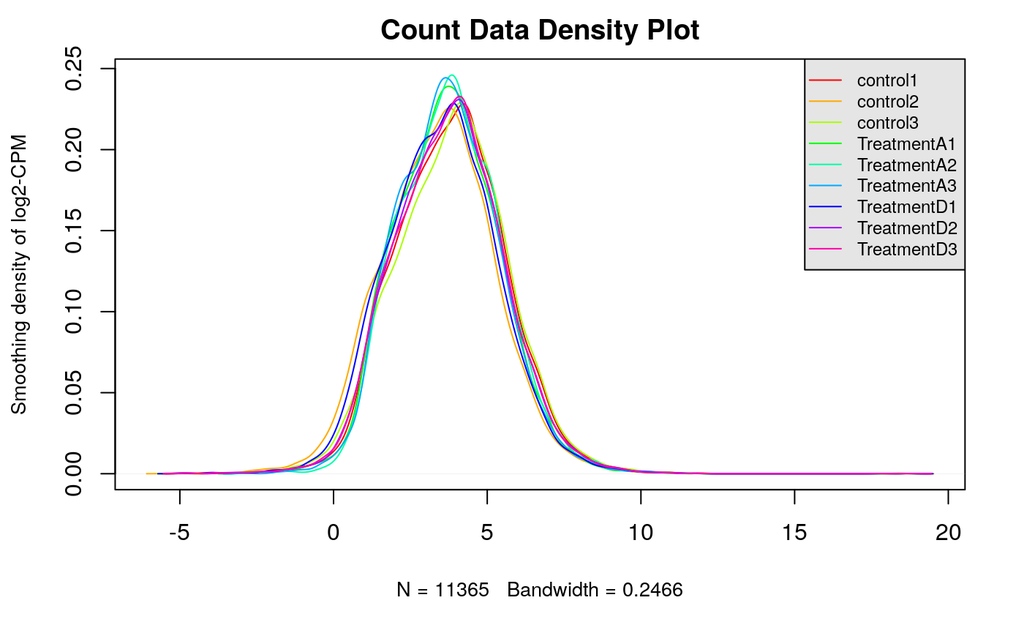

```r
legend("topright", colnames(genes_expression[2:10]),
col=cols, lty=ltys, cex=0.75,
border ="blue", text.col = "black",
merge = TRUE, bg = "gray90")
```

It seems that data follows a normal distribution pattern.

MA plot

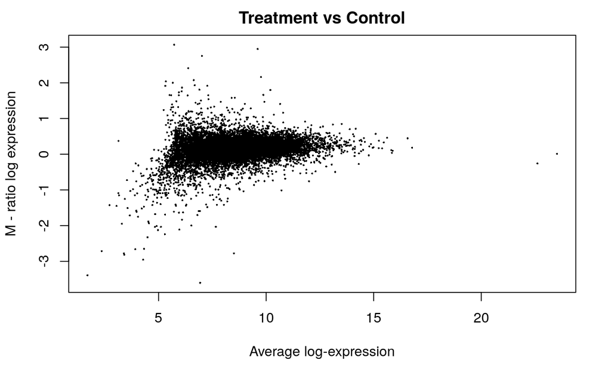

```r
plotMA(log2(genes_filtered[,c(2:4,5:7,8:10)]), ylab="M - ratio log expression",
main="Treatment vs Control")
```

# 4. Mapping

To perform mapping, hgnc_symbol is selected

```r
ensembl <- useMart("ensembl")
ensembl = useDataset("hsapiens_gene_ensembl",mart=ensembl)
gene_mapped <- getBM(attributes = c("ensembl_gene_id","hgnc_symbol"),
filters = c("hgnc_symbol"),
values = genes_filtered$hgnc_symbol,
mart = ensembl)
```

```r
length(which(rownames(cpms) %in%
gene_mapped$hgnc_symbol))
```

```
[1] 10089
```

Total number of genes with measurements

```r
nrow(cpms)
```

```
[1] 23373
```

Number of genes that could not be mapped

```r
nrow(cpms) - length(which(rownames(cpms) %in%
gene_mapped$hgnc_symbol))
```

```
[1] 13284
```

Merging raw data and mapped genes; presenting first 6 rows in all cases

```r
cpms_annot <- merge(gene_mapped,cpms,
by.x = 2, by.y = 0, all.y=TRUE)
kable(cpms_annot[1:6,],format = "html")
```

| hgnc_symbol | ensembl_gene_id | control1 | control2 | control3 | TreatmentA1 | TreatmentA2 | TreatmentA3 | TreatmentD1 | TreatmentD2 | TreatmentD3 |
| --- | --- | --- | --- | --- | --- | --- | --- | --- | --- | --- |
| __alignment_not_unique | NA | 4.225227e+05 | 4.444428e+05 | 4.162802e+05 | 3.658093e+05 | 4.237705e+05 | 4.110355e+05 | 4.411324e+05 | 4.340936e+05 | 4.211245e+05 |
| __ambiguous | NA | 4.207742e+03 | 3.345959e+03 | 4.159751e+03 | 3.459126e+03 | 3.875642e+03 | 3.538891e+03 | 3.556330e+03 | 3.989088e+03 | 3.793307e+03 |
| __no_feature | NA | 2.043480e+05 | 2.668395e+05 | 2.025343e+05 | 3.208292e+05 | 2.269080e+05 | 2.668490e+05 | 2.497227e+05 | 2.117797e+05 | 2.328323e+05 |
| __not_aligned | NA | 0.000000e+00 | 0.000000e+00 | 0.000000e+00 | 0.000000e+00 | 0.000000e+00 | 0.000000e+00 | 0.000000e+00 | 0.000000e+00 | 0.000000e+00 |
| __too_low_aQual | NA | 0.000000e+00 | 0.000000e+00 | 0.000000e+00 | 0.000000e+00 | 0.000000e+00 | 0.000000e+00 | 0.000000e+00 | 0.000000e+00 | 0.000000e+00 |
| 1/2-SBSRNA4 | NA | 8.727438e-01 | 6.471153e-01 | 1.147051e+00 | 1.090341e+00 | 1.106123e+00 | 9.835716e-01 | 5.097082e-01 | 8.662187e-01 | 9.694756e-01 |

- Another method to check ensembl ID missing genes.

```r
length(ensembl_id_missing_gene <- cpms_annot$ensembl_gene_id[
which(is.na(cpms_annot$ensembl_gene_id))])
```

```
[1] 13284
```

Presenting the first 10 ensembl IDs that do not match with HUGO

```r
kable(cpms_annot[which(is.na(cpms_annot$ensembl_gene_id)),], format = "pipe")[1:12]
```

```
 [1] "|      |hgnc_symbol            |ensembl_gene_id |     control1|     control2|     control3|  TreatmentA1|  TreatmentA2|  TreatmentA3|  TreatmentD1|  TreatmentD2|  TreatmentD3|"
 [2] "|:-----|:----------------------|:---------------|------------:|------------:|------------:|------------:|------------:|------------:|------------:|------------:|------------:|"
 [3] "|1     |__alignment_not_unique |NA              | 4.225227e+05| 4.444428e+05| 4.162802e+05| 3.658093e+05| 4.237705e+05| 4.110355e+05| 4.411324e+05| 4.340936e+05| 4.211245e+05|"
 [4] "|2     |__ambiguous            |NA              | 4.207742e+03| 3.345959e+03| 4.159751e+03| 3.459126e+03| 3.875642e+03| 3.538891e+03| 3.556330e+03| 3.989088e+03| 3.793307e+03|"
 [5] "|3     |__no_feature           |NA              | 2.043480e+05| 2.668395e+05| 2.025343e+05| 3.208292e+05| 2.269080e+05| 2.668490e+05| 2.497227e+05| 2.117797e+05| 2.328323e+05|"
 [6] "|4     |__not_aligned          |NA              | 0.000000e+00| 0.000000e+00| 0.000000e+00| 0.000000e+00| 0.000000e+00| 0.000000e+00| 0.000000e+00| 0.000000e+00| 0.000000e+00|"
 [7] "|5     |__too_low_aQual        |NA              | 0.000000e+00| 0.000000e+00| 0.000000e+00| 0.000000e+00| 0.000000e+00| 0.000000e+00| 0.000000e+00| 0.000000e+00| 0.000000e+00|"
 [8] "|6     |1/2-SBSRNA4            |NA              | 8.727438e-01| 6.471153e-01| 1.147051e+00| 1.090341e+00| 1.106123e+00| 9.835716e-01| 5.097082e-01| 8.662187e-01| 9.694756e-01|"
 [9] "|7     |A1BG                   |NA              | 0.000000e+00| 0.000000e+00| 3.186250e-02| 4.038300e-02| 1.070442e-01| 1.341234e-01| 3.185680e-02| 3.766170e-02| 0.000000e+00|"
[10] "|8     |A1BG-AS1               |NA              | 0.000000e+00| 0.000000e+00| 0.000000e+00| 0.000000e+00| 0.000000e+00| 0.000000e+00| 3.185680e-02| 3.766170e-02| 0.000000e+00|"
[11] "|10    |A2LD1                  |NA              | 2.653141e+00| 2.264904e+00| 2.708316e+00| 2.463362e+00| 3.175644e+00| 2.816591e+00| 2.452971e+00| 2.448009e+00| 1.615793e+00|"
[12] "|11    |A2M                    |NA              | 4.538268e-01| 4.728920e-01| 5.098007e-01| 8.884257e-01| 5.352209e-01| 7.153248e-01| 6.052785e-01| 5.649253e-01| 8.258496e-01|"
```

Old mapping

# 5. Normalization

Checking potential duplication

```r
summary(duplicated(gene_mapped$ensembl_gene_id))
```

```
   Mode   FALSE
logical   11166
```

```r
summary(duplicated(gene_mapped$hgnc_symbol))
```

```
   Mode   FALSE    TRUE
logical   10089    1077
```

Removing duplication, and creating appropriate file to perform normalization analysis

```r
gene_mapped_unique <- unique(gene_mapped$hgnc_symbol)
gene_mapped_unique <- data.frame(gene_mapped_unique)
rownames(gene_mapped_unique) <- gene_mapped_unique$gene_mapped_unique
gene_mapped_unique_counts = genes_expression[which(rownames(gene_mapped_unique)%in% genes_expression$hgnc_symbol),]

gene_mapped_unique_Cont_TA <- unique(gene_mapped$hgnc_symbol)
gene_mapped_unique_Cont_TA <- data.frame(gene_mapped_unique_Cont_TA)
rownames(gene_mapped_unique_Cont_TA) <- gene_mapped_unique_Cont_TA$gene_mapped_unique_Cont_TA
gene_mapped_unique_counts_Cont_TA = genes_expression[which(rownames(gene_mapped_unique_Cont_TA)%in% genes_expression$hgnc_symbol),]
```

MA Plot

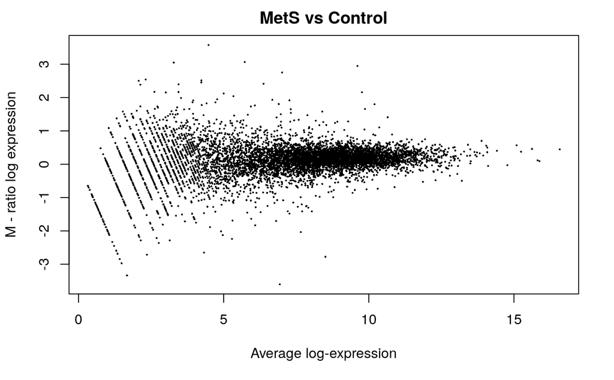

```r
plotMA(log2(gene_mapped_unique_counts[,c(2:4,5:7,8:10)]), ylab="M - ratio log expression",main="MetS vs Control")
```

Trimmed Mean of M-values (TMM)

```r
filtered_data_matrix <- as.matrix(gene_mapped_unique_counts[,2:10])
rownames(filtered_data_matrix) <- gene_mapped_unique_counts$hgnc_symbol
d = DGEList(counts=filtered_data_matrix, group = dataSamples$Agent)
filtered_data_matrix_con_TA <- as.matrix(gene_mapped_unique_counts[,2:7])
rownames(filtered_data_matrix_con_TA) <- gene_mapped_unique_counts$hgnc_symbol
d_control_versus_TreatmentA <- DGEList(counts=filtered_data_matrix_con_TA, group = dataSamples_control_versus_TReatmentA$Agent)
```

Normalization factors

```r
d = calcNormFactors(d)
d$samples[1:9,]
```

|  | group | lib.size | norm.factors |
| --- | --- | --- | --- |
| control1 | Vehicle | 4663352 | 0.9858543 |
| control2 | Vehicle | 5016253 | 0.9742314 |
| control3 | Vehicle | 5212349 | 0.9673308 |
| TreatmentA1 | AZD | 3424733 | 1.0419864 |
| TreatmentA2 | AZD | 4326418 | 1.0090235 |
| TreatmentA3 | AZD | 3191639 | 1.0578584 |
| TreatmentD1 | DBZ | 4195323 | 0.9800913 |
| TreatmentD2 | DBZ | 4120687 | 0.9855747 |
| TreatmentD3 | DBZ | 4209774 | 1.0018512 |

```r
d_control_versus_TreatmentA = calcNormFactors(d_control_versus_TreatmentA)
d_control_versus_TreatmentA$samples[1:6,]
```

|  | group | lib.size | norm.factors |
| --- | --- | --- | --- |
| control1 | Vehicle | 4663352 | 0.9804812 |
| control2 | Vehicle | 5016253 | 0.9689217 |
| control3 | Vehicle | 5212349 | 0.9620586 |
| TreatmentA1 | AZD | 3424733 | 1.0363074 |
| TreatmentA2 | AZD | 4326418 | 1.0035241 |
| TreatmentA3 | AZD | 3191639 | 1.0520929 |

```r
#kable(d$samples[,], format = "html") %>% row_spec(c(1,8,9,10), background = "yellow")
```

```r
normalized_counts <- cpm(d)
normalized_counts_vehicle_TreatmentA <- cpm(d_control_versus_TreatmentA)
```

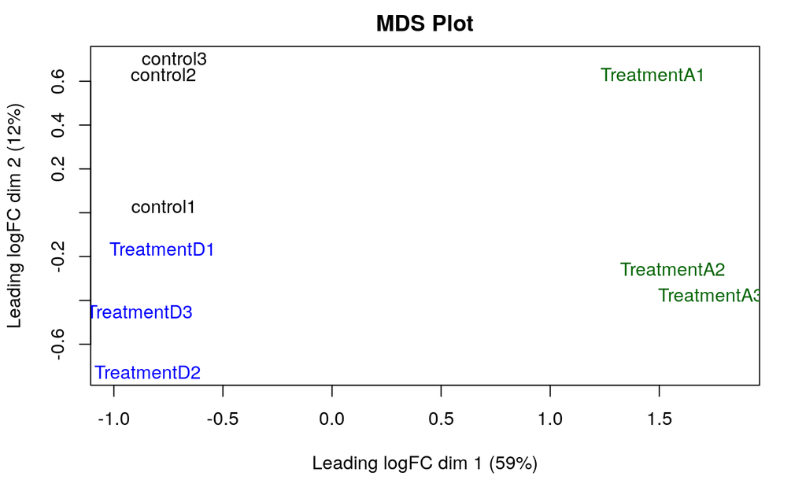

```r
plotMDS(d, labels=rownames(dataSamples), col = c("darkgreen","blue")[factor(dataSamples$Agent)], main="MDS Plot")
```

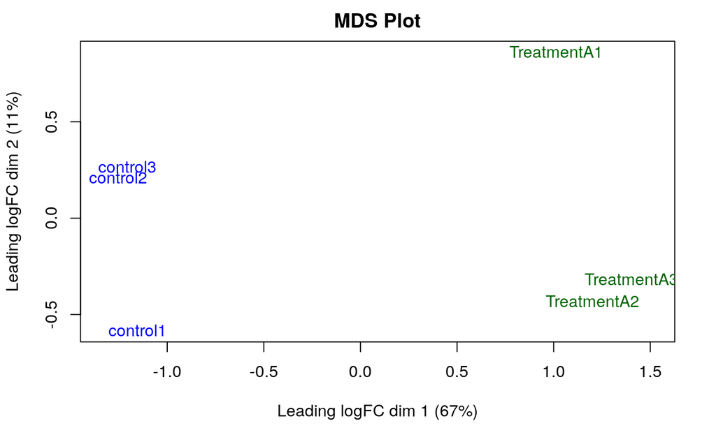

```r
plotMDS(d_control_versus_TreatmentA, labels=rownames(dataSamples_control_versus_TReatmentA), col = c("darkgreen","blue")[factor(dataSamples_control_versus_TReatmentA$Agent)], main="MDS Plot")
```

```r
model_design <- model.matrix(~dataSamples$Agent)
```

```r
d <- estimateDisp(d, model_design)
```

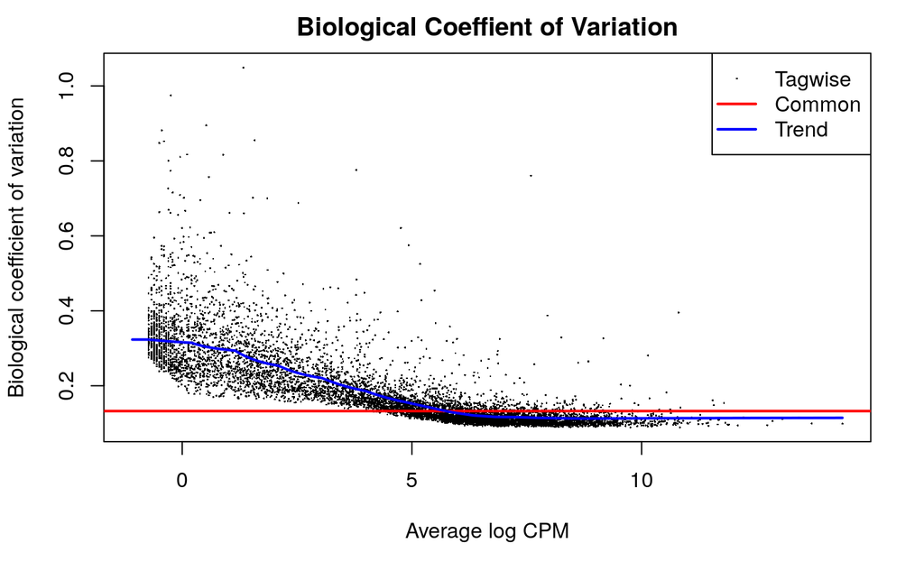

```r
plotBCV(d,col.tagwise = "black",col.common = "red",col.trend = "blue", main="Biological Coeffient of Variation")
```

# Assignment 2

… using the normailzed counts file created in the assignment 1 as:

```r
normalized_count_annot_Cont_TA <- merge(gene_mapped,
normalized_counts_vehicle_TreatmentA, by.x = 2, by.y = 0, all.y = TRUE)

summary(duplicated(normalized_count_annot_Cont_TA$ensembl_gene_id)) #checking duplicated gene_id
```

```
   Mode   FALSE    TRUE
logical    4924    5665
```

```r
normalized_count_annot_Cont_TA_unique_gene_id <- subset(normalized_count_annot_Cont_TA, !duplicated(normalized_count_annot_Cont_TA$ensembl_gene_id)) #unique gene_id
summary(is.na(normalized_count_annot_Cont_TA_unique_gene_id$ensembl_gene_id)) #there is one missing value
```

```
   Mode   FALSE    TRUE
logical    4923       1
```

```r
normalized_count_annot_Cont_TA_unique_gene_id <- subset(normalized_count_annot_Cont_TA_unique_gene_id, !is.na(normalized_count_annot_Cont_TA_unique_gene_id$ensembl_gene_id)) #missing value removed

summary(duplicated(normalized_count_annot_Cont_TA$hgnc_symbol)) #checking duplicated hgnc_symbol
```

```
   Mode   FALSE    TRUE
logical   10089     500
```

```r
normalized_count_annot_Cont_TA_unique_hgnc_symbol <- subset(normalized_count_annot_Cont_TA, !duplicated(normalized_count_annot_Cont_TA$hgnc_symbol)) #unique hgnc_symbol
summary(is.na(normalized_count_annot_Cont_TA_unique_hgnc_symbol$hgnc_symbol)) #there is no missing value
```

```
   Mode   FALSE
logical   10089
```

# 2. heatmap

## 2.1. heatmap gene_id

```r
heatmap_matrix_gene_id <- normalized_count_annot_Cont_TA_unique_gene_id[,3:8] # creating a numerical matrix over unique gene_id
rownames(heatmap_matrix_gene_id) <- normalized_count_annot_Cont_TA_unique_gene_id$ensembl_gene_id
colnames(heatmap_matrix_gene_id) <- colnames(normalized_count_annot_Cont_TA_unique_gene_id[,3:8])
```

# translating gene numbers to a color scale over gene_id data

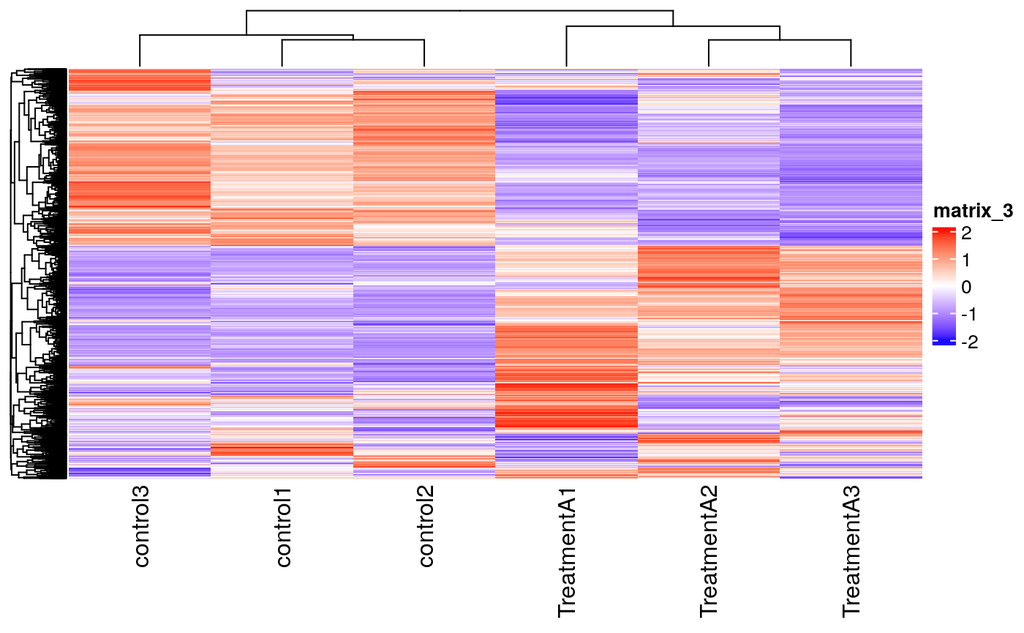

```r
heatmap_matrix_gene_id <- t(scale(t(heatmap_matrix_gene_id)))
if(min(heatmap_matrix_gene_id) == 0){
heatmap_col = colorRamp2(c( 0, max(heatmap_matrix_gene_id)),
c( "white", "red"))
} else {
heatmap_col = colorRamp2(c(min(heatmap_matrix_gene_id), 0,
max(heatmap_matrix_gene_id)), c("blue", "white", "red"))
}
current_heatmap_gene_id <- Heatmap(as.matrix(heatmap_matrix_gene_id),
show_row_dend = TRUE,show_column_dend = TRUE,
col=heatmap_col,show_column_names = TRUE,
show_row_names = FALSE,show_heatmap_legend = TRUE)
current_heatmap_gene_id
```

# 2.3. compairing the expression of genes

## 2.3.1 based on gene_id uniqueness

```r
controls_samples_gene_id <- grep(colnames(normalized_count_annot_Cont_TA_unique_gene_id), pattern = "^c")
TreatmentA_samples_gene_id <- grep(colnames(normalized_count_annot_Cont_TA_unique_gene_id), pattern = "^T")
interested_genes <- which(normalized_count_annot_Cont_TA_unique_gene_id$hgnc_symbol== "PDGFRβ")
```

# 3. creating data matrix

## 3.1.1. gene_id data matrix

```r
gene_id_expressionMatrix <- as.matrix(normalized_count_annot_Cont_TA_unique_gene_id[,3:8])
rownames(gene_id_expressionMatrix) <-
normalized_count_annot_Cont_TA_unique_gene_id$ensembl_gene_id
colnames(gene_id_expressionMatrix) <-
colnames(normalized_count_annot_Cont_TA_unique_gene_id)[3:8]
```

## 3.1.2. creating a linear model

```r
gene_id_modelDesign <- model.matrix(~ dataSamples_control_versus_TReatmentA$Agent)
gene_id_minimalSet <- ExpressionSet(assayData=gene_id_expressionMatrix)
gene_id_fit_simpleModel <- lmFit(gene_id_minimalSet, gene_id_modelDesign)
```

## 3.1.3. fitting data to the simple model

```r
gene_id_minimalSet <- ExpressionSet(assayData=gene_id_expressionMatrix)
gene_id_fit <- lmFit(gene_id_minimalSet, gene_id_modelDesign)
```

## 3.1.4. computing differential expression using emprical Bayes

```r
gene_id_fit2 <- eBayes(gene_id_fit,trend=TRUE)
gene_id_topfit <- topTable(gene_id_fit2,
coef=ncol(gene_id_modelDesign),
adjust.method = "BH",
number = nrow(gene_id_expressionMatrix))
gene_id_output_hits <- merge(normalized_count_annot_Cont_TA_unique_gene_id[,1:2],
gene_id_topfit,
by.y=0,by.x=2,
all.y=TRUE)
gene_id_output_hits <- gene_id_output_hits[order(gene_id_output_hits$P.Value),]
```